# Analyse and Share RMD

Lim Ryan

2023-05-04

# Set Up

Before any analysis can be done there are a few things to be set up: -Load the data set into R Studio’s environment (EDIT path)

```r
load("D:/Job/Google Case Study/clean_final.RData")
```

-Install packages

```r
options(repos = c(CRAN = "https://cran.rstudio.com/"))
install.packages("tidyverse")
library(tidyverse)
```

# Overview

Analysis will be done for following: -Trip Length, Distance against Member Types -Member Types, Trip Length, Distance against Rideable Types -Day of the Week, member types -Location

All of these analysis will provide insights into customer’s behaviour. Their similiarties and differences as well as potential opportunities the company can leverage on.

## Trip Length & Distance For Each Member Types

### Removing outliers

Finding Q1 and Q3 of the dataset and finding its IQR. From that i can find out the upper and lower quartile to further clean the data

```r
q1 <- quantile(clean_12_months$trip_length, 0.25)
q3 <- quantile(clean_12_months$trip_length, 0.75)
iqr <- q3 - q1

upper <- q3 + 1.5*iqr
lower <- q1 - 1.5*iqr

clean_12_months <- clean_12_months[clean_12_months$trip_length >= lower & clean_12_months$trip_length <= upper, ]
```

> After removing outliers I performed the analysis again

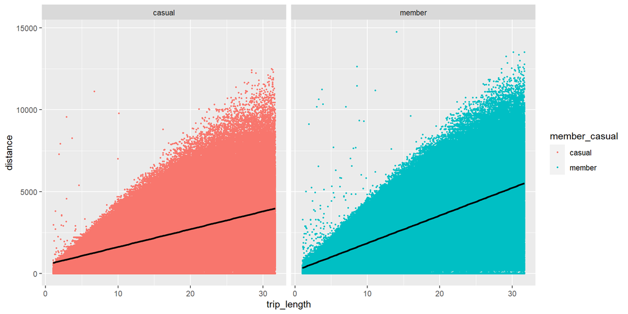

```r
ggplot(clean_12_months, aes(x = trip_length, y = distance, color = member_casual)) +
  geom_point(size = 0.5) +
  geom_smooth(method = "lm", se = FALSE, color = "black") +
  facet_wrap(~ member_casual, ncol = 2)
```

```r
  labs(title = "Trip Length vs. Distance by Member Type",
       x = "Trip Length (minutes)",
       y = "Distance (metres)",
       color = "Member Type") +
  scale_x_continuous(breaks = seq(0, max(clean_12_months$trip_length),5), limits = c(0, max(clean_12_months$trip_length)))
```

## Trip Length & Distance Against Rideable Type

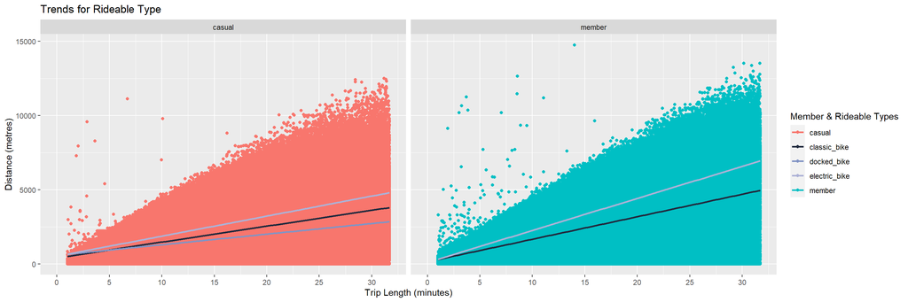

```r
ggplot(clean_12_months, aes(x = trip_length, y = distance, color = member_casual)) +
  geom_point() +
  geom_smooth(method = "lm", se = FALSE, aes(color = rideable_type)) +
  facet_wrap(~ member_casual, ncol = 2) +
  labs(title = "Trends for Rideable Type",
       x = "Trip Length (minutes)",
       y = "Distance (metres)",
       color = "Member & Rideable Types") +
  scale_x_continuous(breaks = seq(0, max(clean_12_months$trip_length), 5), limits = c(0, max(clean_12_months$trip_length))) +
  scale_color_manual(values = c("#F8766D","#212A3E","#8294C4", "#ACB1D6", "#00BFC4"))
```

## Day of the Week Against Member Types

> Finding average ridership for each day of the week for each member type and riderable type

```r
library(data.table)
clean_12_months_dt <- setDT(clean_12_months)
clean_12_months_dt[, day_of_week := factor(recode(day_of_week, "1" = "Sunday", "2" = "Monday", "3" = "Tuesday", "4" = "Wednesday", "5" = "Thursday", "6" = "Friday", "7" = "Saturday"))]
avg_ridership <- clean_12_months_dt[, .(avg_trip_length = mean(trip_length),
                                         avg_distance = mean(distance),
                                         count = .N),
                                    by = c("day_of_week", "member_casual", "rideable_type")]
```

> Group by only member type and day of the week

```r
avg_ridership_member <- clean_12_months_dt[, .(avg_trip_length = mean(trip_length),
                                         avg_distance = mean(distance),
                                         count = .N),
                                    by = c("day_of_week", "member_casual")]
```

> Analysis based on only day of the week and member type

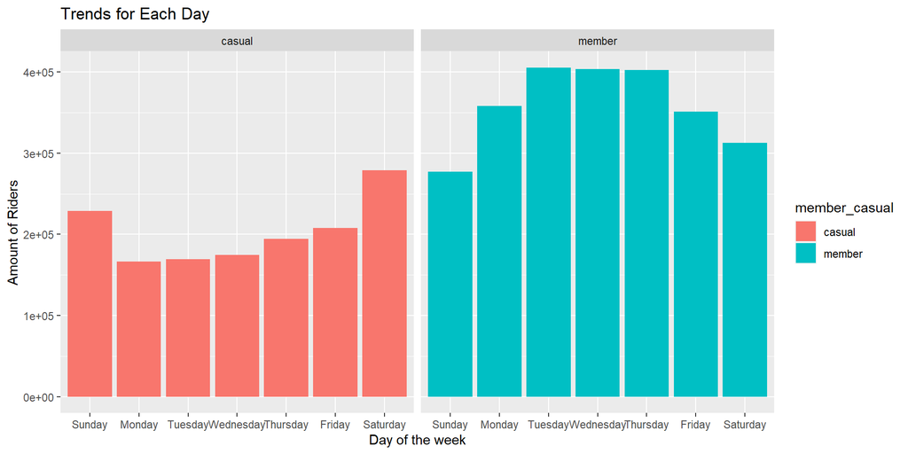

```r
avg_ridership_member$day_of_week <- factor(avg_ridership_member$day_of_week, levels = c("Sunday", "Monday", "Tuesday", "Wednesday", "Thursday", "Friday", "Saturday"))

ggplot(avg_ridership_member, aes(x = day_of_week, y = count, fill = member_casual)) +
  geom_bar(position = "dodge", stat = "identity") +
  facet_wrap(~ member_casual, ncol = 2) +
  labs(title = "Trends for Each Day",
       x = "Day of the week",
       y = "Amount of Riders")
```

> Analysis based on total average trip length for each member type

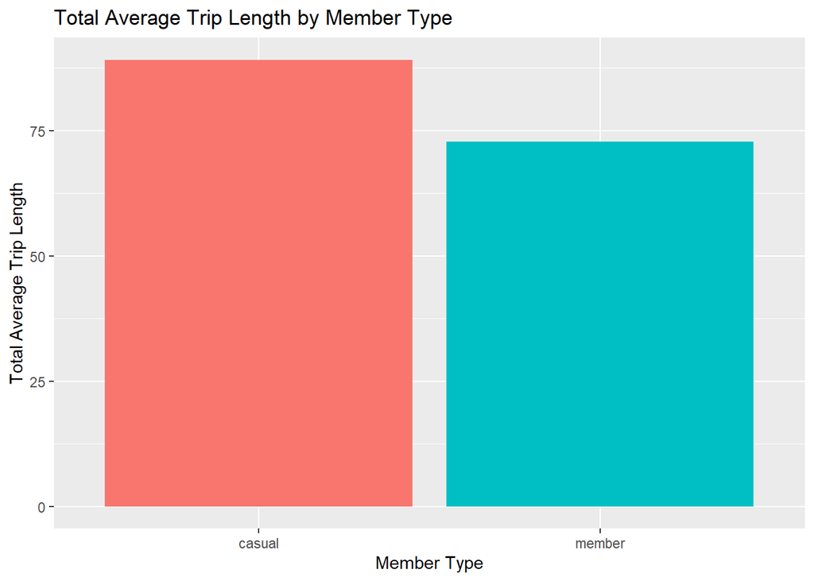

```r
ggplot(avg_ridership_member, aes(x = member_casual, y = avg_trip_length, fill = member_casual)) +
  geom_bar(stat = "identity") +
  labs(title = "Total Average Trip Length by Member Type",
       x = "Member Type",
       y = "Total Average Trip Length") +
  theme(legend.position = "none")
```

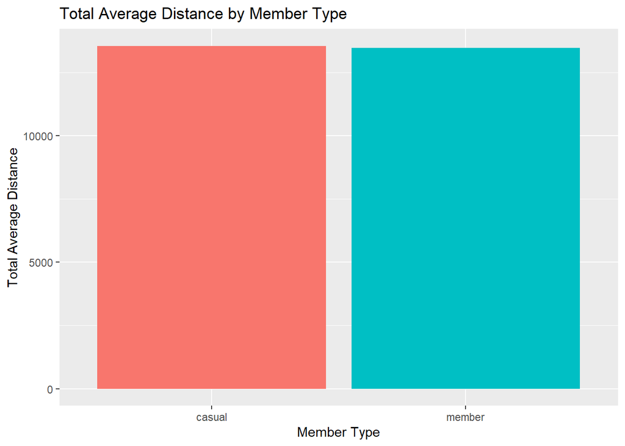

```r
ggplot(avg_ridership_member, aes(x = member_casual, y = avg_distance, fill = member_casual)) +
  geom_bar(stat = "identity") +
  labs(title = "Total Average Distance by Member Type",
       x = "Member Type",
       y = "Total Average Distance") +
  theme(legend.position = "none")
```

> Analyis based on rideable type for each day of the week

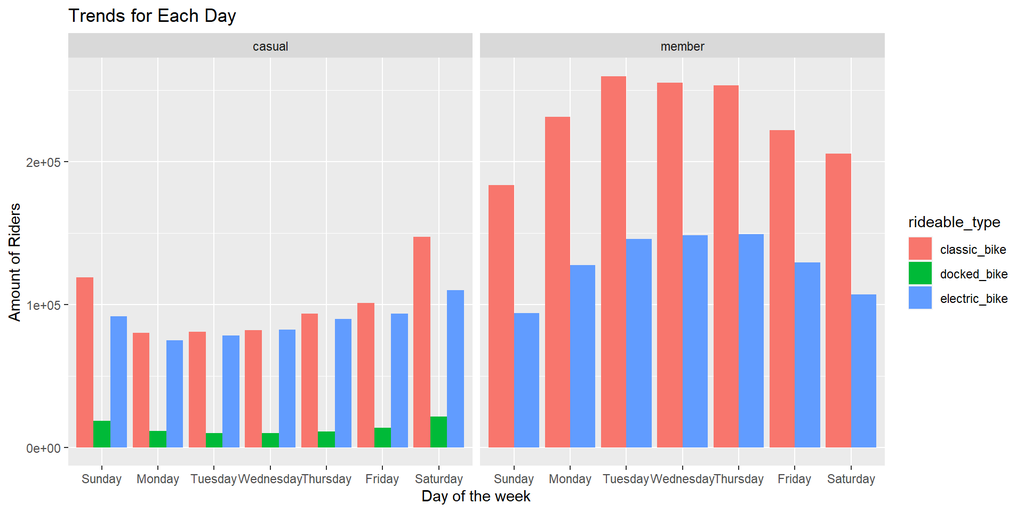

```r
avg_ridership$day_of_week <- factor(avg_ridership$day_of_week, levels = c("Sunday", "Monday", "Tuesday", "Wednesday", "Thursday", "Friday", "Saturday"))

ggplot(avg_ridership, aes(x = day_of_week, y = count, fill = rideable_type)) +
  geom_bar(position = "dodge", stat = "identity") +
  facet_wrap(~ member_casual, ncol = 2) +
  labs(title = "Trends for Each Day",
       x = "Day of the week",
       y = "Amount of Riders")
```

> Analysis based on rideable type for average trip length

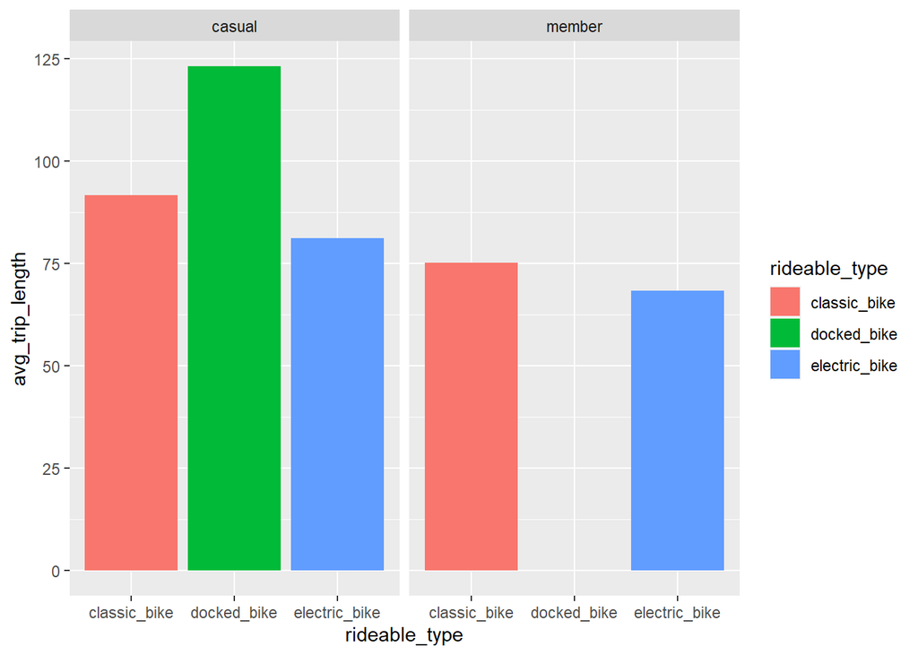

```r
ggplot(avg_ridership, aes(x = rideable_type, y = avg_trip_length, fill = rideable_type)) +
  geom_bar(stat = "identity") +
  facet_wrap(~ member_casual, ncol = 2)
```

```r
  labs(title = "Total Average Trip Length by Rideable Type",
       x = "Member Type",
       y = "Total Average Trip Length") +
  theme(legend.position = "none")
```

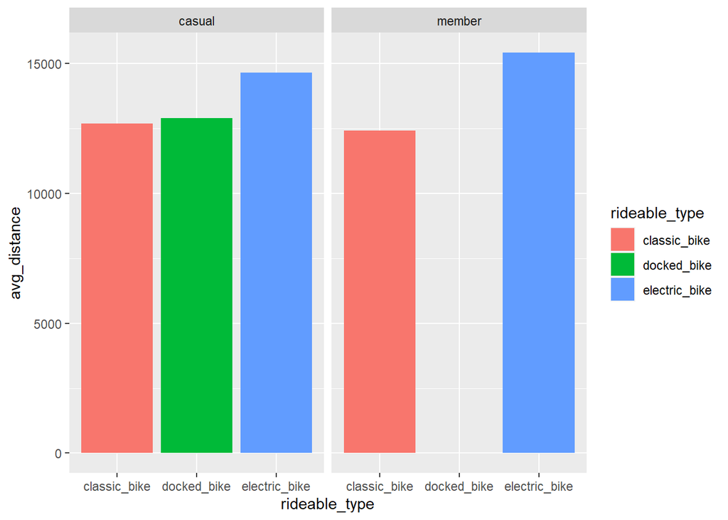

```r
ggplot(avg_ridership, aes(x = rideable_type, y = avg_distance, fill = rideable_type)) +
  geom_bar(stat = "identity") +
  facet_wrap(~ member_casual, ncol = 2)
```

```r
  labs(title = "Total Average Distance by Rideable Type",
       x = "Member Type",
       y = "Total Average Distance") +
  theme(legend.position = "none")
```

## Location for Each Member Type

> Counting Frequency of Each Location

```r
location_counts <- as.data.frame(table(clean_12_months$start_station_name))
```

> Finding Top 5 Locations

```r
top_locations <- location_counts %>%
  arrange(desc(Freq)) %>%
  slice(1:5)
```

> Chart to a map

```r
install.packages("leaflet")
```

```r
library(leaflet)

locations <- data.frame(location = c("Streeter Dr & Grand Ave", "Wells St & Concord Ln", "DuSable Lake Shore Dr & North Blvd", "Clark St & Elm St", "Kingsbury St & Kinzie St"),
                        lat = c(41.89203, 42.02824, 41.91021, 41.90269, 41.88962),
                        lng = c(-87.61282, -87.67483, -87.60788, -87.63032, -87.64414))

# create a leaflet map with markers for each location
leaflet(locations) %>%
  addTiles() %>%
  addMarkers(~lng, ~lat, popup = ~location)
```

[interactive chart not shown]